# Bio-Efficacy Dose-Response Report: Ryegrass

Author

Keith Post

Published

January 11, 2026

**[PASS] Robust Signal: This dataset provides high confidence for parameter estimation.**

## Data Quality & Suitability Audit

### Trial Robustness

- **Signal-to-Noise Ratio (SNR):** In this pipeline, an SNR > 3 is required for reliable parameter estimation; values below this threshold trigger a warning regarding $ED_{50}$ stability. The analysis of this dataset returned an SNR of 16.24, which suggests robust treatment effect with minimal background interference.
- **Dose Coverage:** The ryegrass dataset has a dose ratio of 31.91. This value indicates standard dose coverage for robust non-linear parameter estimation.

### Data Integrity

- **Structural Integrity:** The dataset passed all automated pre-processing checks, confirming appropriate data types and column mapping for ryegrass.
- **Outlier Count:** No outliers were found in the ryegrass dataset.
- **Plateau Status:** The dose range successfully captured the terminal response plateau, providing a high degree of confidence in the upper-limit estimation.

### Visual Audit Summary

The following figure illustrates the distribution of raw data points (replicates) relative to the calculated dose-means. This visualization allows for a direct assessment of the ‘Signal’ (the trend of the blue line) against the ‘Noise’ (the vertical spread of the grey points and error bars).

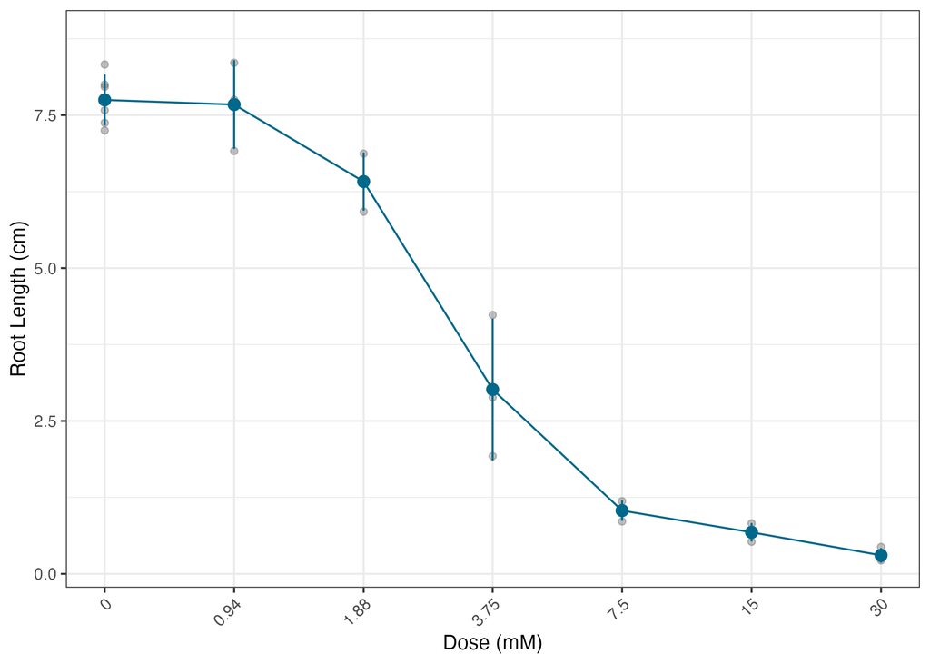

Figure 1: Visual Audit: Distribution of raw replicates across dose levels.

## Dose-Response Analysis & Parameter Estimation

### Modeling Methodology

The data were evaluated against a hierarchy of candidate models to determine the most statistically appropriate and biologically relevant representation of the dose-response relationship.

### Selection Framework

The best-fit model was determined using the following tiered decision logic:

1. **Non-Linear Sigmoidal Evaluation**:
   - Initial attempts were made to fit **Brain-Cousens (Hormetic)**, **Log-Logistic (Standard)**, and **Log-Logistic (Fixed Baseline)** models.
   - If multiple models converged, a **parsimony check** was performed using the Akaike Information Criterion (AIC). A more complex model was only selected if it improved the fit by at least **2 AIC units** over its simpler counterpart.
   - The resulting candidate was then required to demonstrate a **statistically significant slope** ($p < 0.05$).
2. **Linear Fallback**:
   - If sigmoidal models failed to converge or show significance, a **Linear Trend** was evaluated. This model was selected only if it achieved a significant dose-dependent slope ($p < 0.05$).
3. **No Detectable Response (Null)**:
   - If all previous attempts failed to detect a significant relationship, the dataset was categorized as having **No Detectable Response**, utilizing an intercept-only model.

### Model Selection

The biological response was characterized using a **Log-Logistic (Standard)** function. This selection was based on the following criteria: Cleared 2-unit AIC threshold over simpler sigmoids; slope significant (p < 0.05).

### The Final Curve

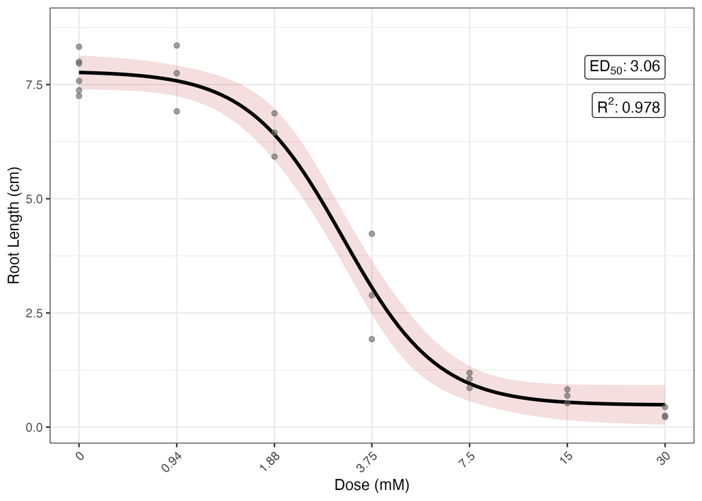

Figure 2: Final Dose-Response Curve: Fitted model for Root Length

## Model Performance & Estimates

The table below summarizes the statistical output and potency estimates for the ryegrass dataset.

| Analysis Model | ED₅₀ Interval | Goodness of Fit (R²) | Decision Rationale |
| --- | --- | --- | --- |
| Log-Logistic (Standard) | 3.06 (2.67 - 3.45) | 0.978 | Cleared 2-unit AIC threshold over simpler sigmoids; slope significant (p &lt; 0.05) |